# Project 2: Classification

**Group 5:** Jeff Nguyen, William Hinton, Adam Ruthford  
**05JUL2020**

# Data Preparation 1

Initial data cleaning and preparation code was derived from **Project 1**, where data types and null values were addressed. Data were first imported into a pandas dataframe, followed by each feature getting set to the appropriate data type based on data dictionary definitions. For example, features that have currencies are set to the float data type as they are a continuous feature; whereas features like **NewExist** is categorical in nature and set to the object data type.

```python
#Import data manipulation, vizulization, and ML Packages
import pandas as pd
import time
nbstart = time.time()
#load data into pandas dataframe
loans = pd.read_csv('C:/Users/Jeff/Desktop/ML1/SBAnational.csv')
#loans = pd.read_csv('C:\Data\DS7331\Project\should-this-loan-be-approved-or-denied/SBAnational.csv')
```

**DisbursementGross**, **BalanceGross**, **ChgOffPrinGr**, **GrAppv**, **SBA_Appv** are features that deal with currency and are coded as strings which include '$' and ',' characters. Used this website for help with [converting currency to float.](https://stackoverflow.com/questions/32464280/converting-currency-with-to-numbers-in-python-pandas)

```python
import numpy as np

# Create lists of features that need their data types converted
currency = ['DisbursementGross','BalanceGross','ChgOffPrinGr','GrAppv','SBA_Appv']
date = ['ApprovalDate','ChgOffDate','DisbursementDate']
cat_variables = ['Zip']

# Convert features to appropriate data types
loans[currency] = loans[currency].replace('[\$,]', '', regex=True).astype(float)
loans[date]= loans[date].astype(np.datetime64)
loans['NewExist'] = loans['NewExist'].astype('Int64')
loans[cat_variables] = loans[cat_variables].astype(str)
```

```python
# Replace City NA with appropriate state/city name
cityList = ['Salt Lake City','New Orleans','Chicago','Chicago','San Diego','San Diego','San Diego','San Diego',
            'San Diego','San Diego','Clevland','St. Louis','St. Louis','St. Louis','St. Louis','St. Louis',
            'St. Louis','Seattle','Des Moines','San Antonio','Kansas City','Kansas City','Quincy','Quincy','Boston',
            'NaN','NaN','Louisville','Wilmington','Flint']
stateList = ['NaN','NaN','CA','AP','KS','TX','FL','WI','NJ','UT','MO','TX','TX','TX']

#Replace Cities with NAs with appropriate City or State
loans.loc[loans.City.isnull(),'City'] = cityList
loans.loc[loans.State.isnull(),'State'] = stateList
```

A new feature called **difference_in_days** was created by subtracting DisbursementDate minus ApprovalDate. This will explain the relationship between time the loan was approved to disbursement date. There may be some correlation to why a loan is defaulted on depending on disbursement date.

```python
#Create new Time feature and convert to int
from datetime import datetime, timedelta
d1 = loans.DisbursementDate
d2 = loans.ApprovalDate
def days_between(d1, d2):
    d1 = datetime.strptime(d1, "%d-%m-%Y")
    d2 = datetime.strptime(d2, "%d-%m-%Y")
    return abs((d2 - d1).days)

difference_in_days = abs((d2-d1))/ timedelta(days=1)

loans['difference_in_days'] = difference_in_days
```

Addressing 1997 null records for MIS_Status was unique in that it was depedent on several attributes in the dataset. There were four different combinations of code used to address the null records for this feature. The first combination identified null values that had a non-null value in the ChgOffDate feature and that the ChgOffPrinGr feature was not equal to zero; this combination of conditional requirements identified records that defaulted and had a charge off balance and renamed the null values as "CHGOFF". The second combination identified null values where DisbursementDate was not null and the BalanceGross was equal to zero; this combination of features identifies records that did not receive funds and do not have a balance, this labeled the null values as "P I F". The third and fourth combination identify null MIS_Status records where funds were not disbursed by checking DisbursementGross and BalanceGross features. If the DisbursementGross was zero or null and the BalanceGross was 0, the missing data was labels as "Not Disbursed".

```python
#--------------------------------------------------------------------------------------------------------------------
#Fill In NaN fields
loans.dropna(subset = ['Name'], inplace = True)
loans["Bank"].fillna("Not Listed", inplace = True)
loans["BankState"].fillna("Not Listed", inplace = True)
loans['NewExist'].fillna(0, inplace = True)
loans['RevLineCr'].fillna("Not Provided", inplace = True)
loans['LowDoc'].fillna("Not Provided", inplace = True)
loans['ChgOffDate'].fillna("0000-00-00",inplace = True)
loans['DisbursementDate'].fillna("0000-00-00",inplace = True)

#Replace NaT MIS_status with CHGOFF if their ChgOffDate is not null
#If MIS_Status has value,
loans['MIS_Status'].mask((loans['MIS_Status'].isnull()) &
                         ((loans['ChgOffDate'].notnull()) |
                          (loans['ChgOffPrinGr']!=0.0)),'CHGOFF',inplace=True)

loans['MIS_Status'].mask((loans['MIS_Status'].isnull()) &
                         (loans['DisbursementDate'].notnull()) &
                         (loans['BalanceGross']==0.0),'P I F',inplace=True)

loans['MIS_Status'].mask((loans['MIS_Status'].isnull()) &
                         (loans['DisbursementGross'].isnull()) &
                         (loans['BalanceGross']==0.0),'Not Disbursed',inplace=True)

loans['MIS_Status'].mask((loans['MIS_Status'].isnull()) &
                         (loans['DisbursementGross']==0.0) &
                         (loans['BalanceGross']==0.0),'Not Disbursed',inplace=True)

#--------------------------------------------------------------------------------------------------------------------
loans['MIS_Status'].replace(to_replace = 'P I F', value = 1, inplace = True)
loans['MIS_Status'].replace(to_replace = 'CHGOFF', value = 0, inplace = True)
```

After null values were removed, the index was reset for the loans data frame. When rows are removed from a data frame, the index for that row remains. If the indcies are not reset, null values will be assigned to indicies that had rows removed. Since sklearn algorithms require matricies and arrays, when a data frame with surplus incies are converted to a matrix, there will be a shape mismatch causing an error. The .info() function was run to check on null values and the range index.

```python
loans = loans.dropna()#drops 14 records
loans = loans.reset_index(drop=True) #resets index, important when converting to array
```

```python
loans.info()
```

```
<class 'pandas.core.frame.DataFrame'>
RangeIndex: 896782 entries, 0 to 896781
Data columns (total 28 columns):
 #   Column              Non-Null Count   Dtype
---  ------              --------------   -----
 0   LoanNr_ChkDgt       896782 non-null  int64
 1   Name                896782 non-null  object
 2   City                896782 non-null  object
 3   State               896782 non-null  object
 4   Zip                 896782 non-null  object
 5   Bank                896782 non-null  object
 6   BankState           896782 non-null  object
 7   NAICS               896782 non-null  int64
 8   ApprovalDate        896782 non-null  datetime64[ns]
 9   ApprovalFY          896782 non-null  object
```

[output cut: 20 more lines]

## Response and Explanatory Feature Descriptions, and Feature Engineering

### Response Feature

Three features in the SBAnational dataset can serve as response variables. Two are continuous and one is categorical. These features were choosen to be response variables as they are good indicators of loan success or failure.

**CreateJob and RetainedJob:** These columns are presented as an integer. The column records the number of jobs created or retained, respectively. These variables cannot be used as explanatory variables as they indicate the success of the loan. They are a proxy for loan success. However, these variables can be used as the response variable in a model that would attempt to maximize job creation and or retention. Thus, any of these response terms correlated with explanatory terms are significant and noteworthy due to their possible predictive power. Since we are more interested in the classification of accounts having paid in full or were charged off; these featuers will be exclued from the model.

**MIS_Status:** This column is presented as an object/string. The column is categorical data with values "P I F" and "CHGOFF". This column is the main response column of the dataset. This feature will be used to determine if a loan has succeeded or failed, where 'P I F' is a success, and a 'CHGOFF' is a failure. Approximately 18% of loans were marked for a 'CHGOFF' and 82% successful repaid their loans. This feature will serve as the response feature for our logistic and SVM models as it is dichotmous and indicates whether or not a loan applicant has paid their loan back or not. **MIS_Status** will also be converted to numeric values instead of character for use in the model.

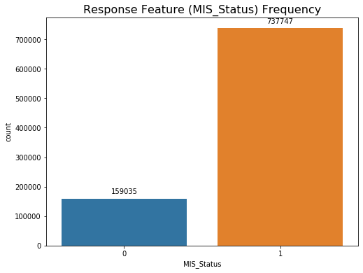

```python
import matplotlib.pyplot as plt
import seaborn as sns

plt.figure(figsize=(8, 6))
ax = sns.countplot(x =loans['MIS_Status'] )
plt.title("Response Feature (MIS_Status) Frequency",fontsize= 16)

for p in ax.patches:
    ax.annotate(p.get_height(),
                (p.get_x() + p.get_width() / 2, p.get_height()),  ha = 'center', va = 'center',
                xytext = (0, 10), textcoords = 'offset points')
```

### Explanatory Features

**ApprovalDate**, **DisbursementDate**, and **ChgOffDate** are features that contain dates. Since there are a large volume of dates, these features would not be suited for conversion to categorical features unless they were binned. **ApprovalFY** is similar to **ApprovalDate** and may better be suited for use in the model; this feature can be binned to reduce the number of levels in the feature. This model does not address time series analysis or autocorrelation structures. If a record contains a value from **ChgOffDate**, then the loan defaulted. This information is more sussenctly captured in the **MIS_Status** level 'CHGOFF'; due to the redundancy **ChgOffDate** would be more useful in a new feature that captures a time difference with another time feild.

One assumption for logistic regression is minimal multicollinearity. **DisbursmentGross**, **GRAppv**, and **SBA_Appv** are highly correlated (r > 0.90) with each other as they all describe the amount of money that is given to a loan applicant. **SBA_Appv** will be kept, while **DisbursementGross** and **GrAppv** will be removed as they are both like **SBA_Appv**, but do not represent the final loan amount an applicant will receive. Please see the correlation matrix in the **Data Preparation** section for more details.

### Feature Engineering

**State**, **Bank**, **NAICS**, **ApprovalFY,** NewExist**,** UrbanRural**,** RevlineCr**, and** LowDoc** are features that require binning and/or one-hot-encoding. These features may require additional cleaning and may have many categories. Consolidating the number of categories can assist with reducing overfitting and reduce the computational load it would take to find weights for the numerous levels that exist in some of the features.

#### Categorical Features

**Bank** contains over 5,803 unique levels. Using this many levels in a model may lead to overfitting. To avoid this situation the large volume of banks will be reduced by consolidating and binning into nine bins. These bins will contain the top eight banks, and an 'other' category containing the other smaller banks. The other category was created by renaming all banks that were not in the 'major_banks' list to 'other'. The .describe() function was then run on the modified feature to confirm that the correct number of categories were created.

```python
loans['Bank'].value_counts().head(15)
```

```
BANK OF AMERICA NATL ASSOC        86498
WELLS FARGO BANK NATL ASSOC       63371
JPMORGAN CHASE BANK NATL ASSOC    47730
U.S. BANK NATIONAL ASSOCIATION    35068
CITIZENS BANK NATL ASSOC          34861
PNC BANK, NATIONAL ASSOCIATION    27285
BBCN BANK                         22887
CAPITAL ONE NATL ASSOC            22244
MANUFACTURERS & TRADERS TR CO     11246
READYCAP LENDING, LLC             10656
THE HUNTINGTON NATIONAL BANK       9587
KEYBANK NATIONAL ASSOCIATION       9249
TD BANK, NATIONAL ASSOCIATION      8982
BRANCH BK. & TR CO                 8251
ZIONS FIRST NATIONAL BANK          7943
Name: Bank, dtype: int64
```

```python
# Banks create buckets for top 19 banks + other
major_bank = ['BANK OF AMERICA NATL ASSOC', 'WELLS FARGO BANK NATL ASSOC',
              'JPMORGAN CHASE BANK NATL ASSOC','U.S. BANK NATIONAL ASSOCIATION',
              'CITIZENS BANK NATL ASSOC','PNC BANK, NATIONAL ASSOCIATION',
             'BBCN BANK','CAPITAL ONE NATL ASSOC']

loans.loc[~loans["Bank"].isin(major_bank), "Bank"] = "Other"
```

A barchart was also created for the modified **Bank** to visually confirm that there are eight major banks followed by an 'other' category. We can see that the Bank of America is one of the larger banks by loan applicaiton volume followed by Wells Fargo. However, many loans are aquired through other banks, perhaps many of them local. A for loop was applied to show the frequencies of loans that the banks have per bin.

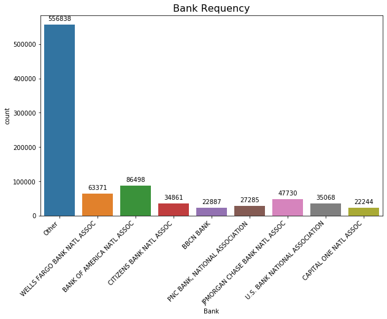

```python
plt.figure(figsize=(10, 6))
ax = sns.countplot(x =loans['Bank'] )
plt.title("Bank Requency",fontsize= 16)
plt.xticks(rotation=45, horizontalalignment='right', fontweight='light', fontsize='medium')

for p in ax.patches:#provides frequency counts
    ax.annotate(p.get_height(),
                (p.get_x() + p.get_width() / 2, p.get_height()),  ha = 'center', va = 'center',
                xytext = (0, 10), textcoords = 'offset points')
```

The North American Industry Classification System (**NAICS**) is used to classify a business into 19+ sectors that specialize in different services. To reduce the number of levels, sectors were grouped based on similar attributes. The list of sectors can be viewed in the 'Data Dictionary' section of this link:https://www.kaggle.com/mirbektoktogaraev/should-this-loan-be-approved-or-denied?select=SBAnational.csv

Sectors were grouped by the first digit in their code as seen below:

- 1 Agriculture
- 2 Mining, Utilities, Construction
- 3 Manufacturing
- 4 Trade and Transportation
- 5 Professional and Scientific
- 6 Education and Health
- 7 Arts and Hospitality
- 8 other
- 9 Public Administration

```python
# create NAICS bins for 0,1,2,3,4,5,6,7,8,9
'NAICS'
loans['NAICS'].replace(to_replace = 0, value = 800000, inplace = True)
loans['NAICS']= pd.cut(loans['NAICS'],
                       [100000,200000,300000,400000,500000,600000,700000,800000,900000,1000000],
                       labels = ['1','2','3','4','5','6','7','8','9'])
```

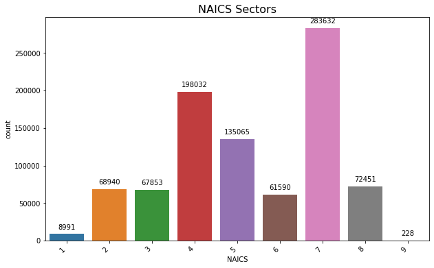

```python
plt.figure(figsize=(10, 6))
ax = sns.countplot(x =loans['NAICS'] )
plt.title("NAICS Sectors",fontsize= 16)
plt.xticks(rotation=45, horizontalalignment='right', fontweight='light', fontsize='medium')

for p in ax.patches:
    ax.annotate(p.get_height(),
                (p.get_x() + p.get_width() / 2, p.get_height()),
                ha = 'center', va = 'center',
                xytext = (0, 10), textcoords = 'offset points')
```

```python
# Create ApprovalFY buckets spread by decade, 1976A need to be cleaned
loans['ApprovalFY'].replace(to_replace = '1976A', value = '1976', inplace = True)
loans['ApprovalFY'] = loans['ApprovalFY'].astype(int)
loans['ApprovalFY_decade']= pd.cut(loans['ApprovalFY'],[1970,1980,1990,2000,2010,2020])
#loans['ApprovalFY_decade'].describe()
```

```python
# look at failure rate at month of term
# decade loan becomes proxy for term
# don't use this feature???
# charge off rate/
```

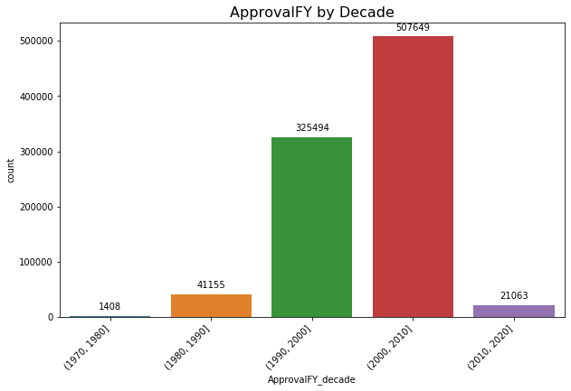

```python
#Bucket ApprovalFY by decade
plt.figure(figsize=(10, 6))
ax = sns.countplot(x =loans['ApprovalFY_decade'] )
plt.title("ApprovalFY by Decade",fontsize= 16)
plt.xticks(rotation=45, horizontalalignment='right', fontweight='light', fontsize='medium')

for p in ax.patches:
    ax.annotate(p.get_height(),
                (p.get_x() + p.get_width() / 2, p.get_height()),
                ha = 'center', va = 'center',
                xytext = (0, 10), textcoords = 'offset points')
```

**RevLineCr**, or Revolving Line of Credit should have values coded "Y" or "N". We can see that there are 18 categories when there should be two. All values coded "0" were converted to "N"; all values with "1" were coded to "Y", and all character values were coded as "N". A plot below confirms that after cleaning that there are two classes.

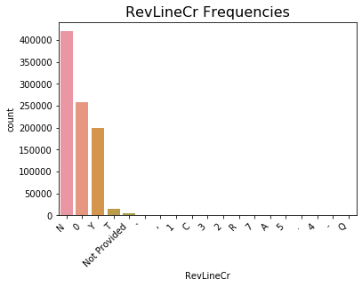

```python
# RevLineCredit: delete special characters 14 total, recode numbers to letters
ax = sns.countplot(x =loans['RevLineCr'] )
plt.title("RevLineCr Frequencies",fontsize= 16)
plt.xticks(rotation=45, horizontalalignment='right', fontweight='light', fontsize='medium')
```

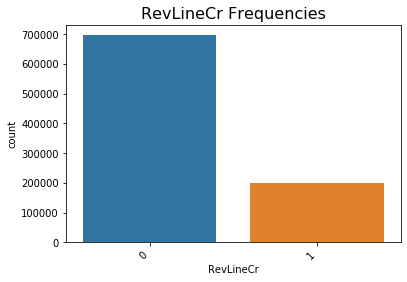

```python
loans['RevLineCr'].replace(to_replace = ['Y','1'], value = 1, inplace = True)
loans['RevLineCr'].replace(to_replace = ['N','0'], value = 0, inplace = True)
no = ['T','`','Not Provided',",",'C','3','2','R','7','A','5','.','4',"'",'Q','-']
loans['RevLineCr'].replace(to_replace = no, value = 0, inplace = True)

ax = sns.countplot(x =loans['RevLineCr'] )
plt.title("RevLineCr Frequencies",fontsize= 16)
plt.xticks(rotation=45, horizontalalignment='right', fontweight='light', fontsize='medium')
```

**LowDoc** has 9 categories when it should have 3. All values with "Y" will be coded as 1; values with "N" will be coded as 0; all other values will be coded as 0. We can see that most loan applicants are not part of the LowDoc loan program in the barchart below. After reorganization we can see that there are 2 categories with 0 being the largest with 788,817 records.

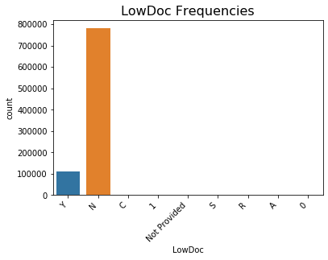

```python
# LowDoc: covert everything to Y or N
ax = sns.countplot(x =loans['LowDoc'] )
plt.title("LowDoc Frequencies",fontsize= 16)
plt.xticks(rotation=45, horizontalalignment='right', fontweight='light', fontsize='medium')
```

```python
loans['LowDoc'].replace(to_replace = ['Y','1'], value = 1, inplace = True)
loans['LowDoc'].replace(to_replace = ['N','0'], value = 0, inplace = True)
no = ['C','S','Not Provided','S','R','A']
loans['LowDoc'].replace(to_replace = no, value = 0, inplace = True)
```

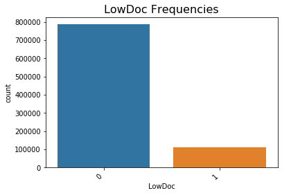

```python
ax = sns.countplot(x =loans['LowDoc'] )
plt.title("LowDoc Frequencies",fontsize= 16)
plt.xticks(rotation=45, horizontalalignment='right', fontweight='light', fontsize='medium')
```

**FRANCHISE CODE** is a feature that describes if a business is a franchise or not and is denoted with '0' being no, and '1' being yes. All records that were not coded as '0' were recoded to '1'. Some examples of this would be records with 'Y', which would then be recoded to '1'. The plot below confirms the cleaning and that two classes remain.

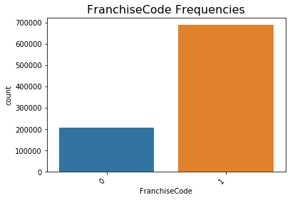

```python
loans['FranchiseCode'].loc[(loans['FranchiseCode'] !=0)] = 1

ax = sns.countplot(x =loans['FranchiseCode'] )
plt.title("FranchiseCode Frequencies",fontsize= 16)
plt.xticks(rotation=45, horizontalalignment='right', fontweight='light', fontsize='medium')
```

There are over 50 categories for the **State** feature, where each category is a state or military address. If all the states were converted via one-hot-encoding, or dummy coding, there would be a risk of overfitting. To address this states will be grouped into the following regions: West, Midwest, Southwest, Southeast, and Northeast.

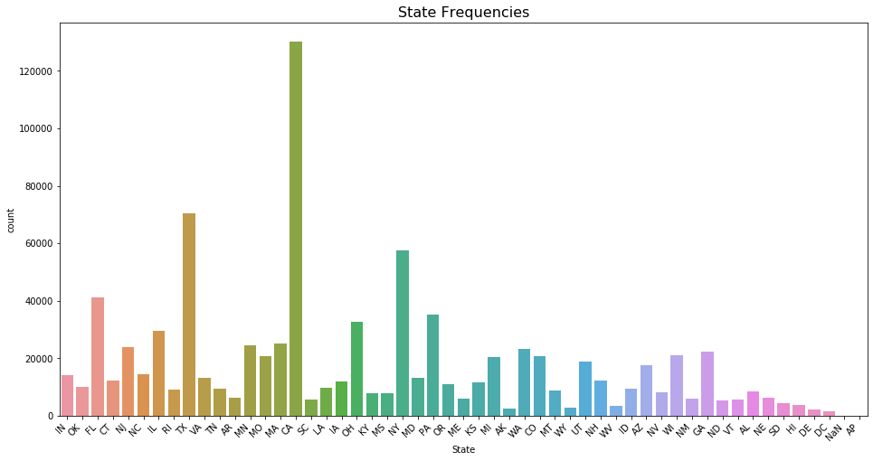

```python
# State Distribution
plt.figure(figsize=(16,8))
ax = sns.countplot(x =loans['State'] )
plt.title("State Frequencies",fontsize= 16)
plt.xticks(rotation=45, horizontalalignment='right', fontweight='light', fontsize='medium')
```

After the **State** feature was binned by region, we can see that the 'West' has the most loan applocations, followed by the 'Northeast' and 'Midwest'. The code below assigns each state to a region based on this map found on National Geographic:https://www.nationalgeographic.org/maps/united-states-regions/

The binning was confirmed by a barchart to ensure that all states were properly assigned to a region. The barchart include frequency counts for ease of reading and was generated using a for loop.

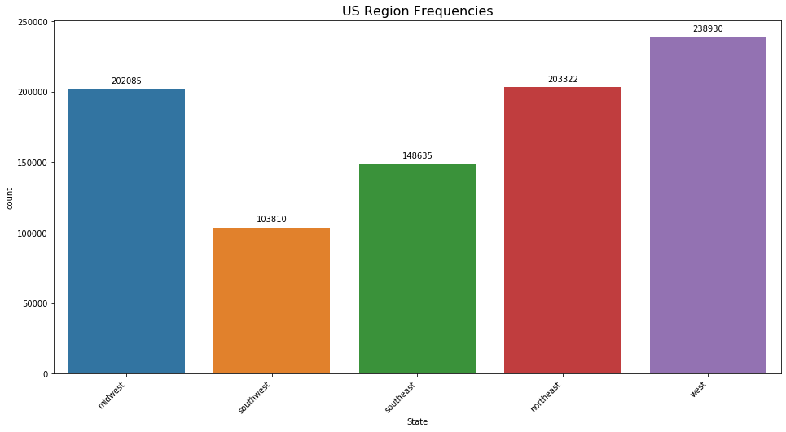

```python
#Generate list of states
west = ['WA','OR','CA','NV','UT','CO','WY','MT','ID','AK','HI','AP','NaN']
midwest =['ND','SD','NE','KS','MO','IA','MN','MI','IL','IN','OH','WI']
southeast = ['AR','LA','MS','TN','KY','WV','VA','NC','SC','GA','FL','AL']
southwest = ['AZ','TX','NM','OK']
northeast = ['ME','VT','NH','CT','RI','NY','NJ','DE','MD','MA','PA','DC']

loans['State'].replace(to_replace = west, value = 'west', inplace = True)
loans['State'].replace(to_replace = midwest, value = 'midwest', inplace = True)
loans['State'].replace(to_replace = southeast, value = 'southeast', inplace = True)
loans['State'].replace(to_replace = southwest, value = 'southwest', inplace = True)
loans['State'].replace(to_replace = northeast, value = 'northeast', inplace = True)

plt.figure(figsize=(16,8))
ax = sns.countplot(x =loans['State'] )
plt.title("US Region Frequencies",fontsize= 16)
plt.xticks(rotation=45, horizontalalignment='right', fontweight='light', fontsize='medium')

for p in ax.patches:
    ax.annotate(p.get_height(),
                (p.get_x() + p.get_width() / 2, p.get_height()),
                ha = 'center', va = 'center',
                xytext = (0, 10), textcoords = 'offset points')
```

#### Categorical One-hot-encoding

**Bank**, **NAICS**, **ApprovalFY_decade**, **UrbanRural**, **NewExist**, and **State** are nominal categorical features and are best represented by one-hot-encoding or as an integer. For our models, these features will be converted to on hot encoding and the old feature will be removed. After one-hot-encoding was complete, the .info() function was run to visually check to ensure that the function created new features and removed the old features. Failure to remove features used to create on-hot-encoded features would introduce multicollinearity. This property would result in an over-inflation of model metrics.

```python
loans = pd.get_dummies(loans,columns=['Bank','NAICS','ApprovalFY_decade',
                                      'UrbanRural','NewExist','State'])

#Clean up dataset
'Bank','NAICS','ApprovalFY_decade'
if 'Bank' in loans:
    del loans['Bank']

if 'NAICS' in loans:
    del loans['NAICS']

if 'ApprovalFY' in loans:
    del loans['ApprovalFY']

if 'State' in loans:
    del loans['State']

if 'UrbanRural' in loans:
    del loans['UrbanRural']

if 'NewExist' in loans:
    del loans['NewExist']
```

```python
loans = loans.dropna()#drops 14 records
loans = loans.reset_index(drop=True) #resets index, important when converting to array
```

```python
loans.info()
```

```
<class 'pandas.core.frame.DataFrame'>
RangeIndex: 896782 entries, 0 to 896781
Data columns (total 56 columns):
 #   Column                               Non-Null Count   Dtype
---  ------                               --------------   -----
 0   LoanNr_ChkDgt                        896782 non-null  int64
 1   Name                                 896782 non-null  object
 2   City                                 896782 non-null  object
 3   Zip                                  896782 non-null  object
 4   BankState                            896782 non-null  object
 5   ApprovalDate                         896782 non-null  datetime64[ns]
 6   Term                                 896782 non-null  int64
 7   NoEmp                                896782 non-null  int64
 8   CreateJob                            896782 non-null  int64
 9   RetainedJob                          896782 non-null  int64
```

[output cut: 48 more lines]

After additional cleaning and binning of the categorical features we can see that the number of unique levels has decreased. Having fewer levels per features should reduce the computational load and potential overfitting when running our classification algorithms.

### Quantitative Features

The correlation matrix below shows continuous features that help determine if a loan is paid in full or if it defaults. The correlation matrix shows that **DisbursementGross** is strongly and positively with **SBA_Appr** and **GrAppv**; and **SBA_Appr** is strongly and positively correlated with **GrAppv**. **NoEmp** and **Term** feature show moderate or low correlation compared to the remaining features. **DisbursementGross**, **SBA_Appr** and **GrAppv** all relate to the amount of money a small business is approved for or received and the correlation matrix shows how strongly correlated those values are. It is most likely that values from DisbursementGross, **SBA_Appr** and **GrAppv** are the same or are very close to each other.

One assumption for logistic regression is minimal multicollinearity. **DisbursmentGross**, **GRAppv**, and **SBA_Appv** are highly correlated (r > 0.90) with each other as they all describe the amount of money that is given to a loan applicant. Since the **SBA_Appv** feature describes the amount of money that is approved and guaranteed to an applicant it will be kept. **DisbursementGross** and **GrAppv** will be removed as they are both like **SBA_Appv**, but do not represent the final loan amount an applicant will receive.

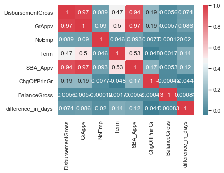

```python
normal_data =['DisbursementGross', 'GrAppv', 'NoEmp', 'Term', 'SBA_Appv','ChgOffPrinGr',
              'BalanceGross','BankState','difference_in_days']
loans_corr = loans[normal_data]

cmap = sns.diverging_palette(220, 10, as_cmap=True) # one of the many color mappings

#Generate a correlation matrix of transformed data
sns.set(style="darkgrid") # one of the many styles to plot using
sns.heatmap(loans_corr.corr(), cmap=cmap, annot=True)
```

#### PCA Features

An alternative to removing highly correlated continuous features is to preform principal component analysis on all continious features, keeping the principal components that explain most of the variation in the continuous data, and removing the features that were used to create the principal components.

```python
from sklearn.preprocessing import StandardScaler #standardizes data
from sklearn.preprocessing import LabelEncoder # converts categories to int

pca_data = ['NoEmp','Term','DisbursementGross','GrAppv','SBA_Appv','difference_in_days']
pca_df = loans[pca_data]

# Standardize continuous data
df_scaled = pd.DataFrame(StandardScaler().fit_transform(pca_df),columns = pca_df.columns)

#Check that data frame is complete
df_scaled.head()
```

|  | NoEmp | Term | DisbursementGross | GrAppv | SBA_Appv | difference_in_days |
| --- | --- | --- | --- | --- | --- | --- |
| 0 | -0.099985 | -0.340615 | -0.491416 | -0.469020 | -0.444992 | 3.277715 |
| 1 | -0.126939 | -0.644810 | -0.560919 | -0.539596 | -0.515010 | -0.116814 |
| 2 | -0.059555 | 0.876162 | 0.297435 | 0.332007 | 0.286922 | 1.021790 |
| 3 | -0.126939 | -0.644810 | -0.578294 | -0.557239 | -0.532515 | 0.042803 |
| 4 | 0.034783 | 1.636648 | 0.095878 | 0.127339 | 0.347094 | -0.207264 |

The scree plot reveals that the first two principal components explain most of the variation in the continous data. These two principal components are contained in the "X_pca" data frame and will be appended to the **loans** data frame, while **NoEmp**, **Term**, **DisbursementGross**, **ChgOffPrinGr**, **GrAppv**, **'difference_in_days'**, and **SBA_Appv** will be removed. This version of the **loans** data will be used to test and compare a logistic model/svm with highly correlated continuous features removed, and a logistic/svm model that utilizes prinicpal components.

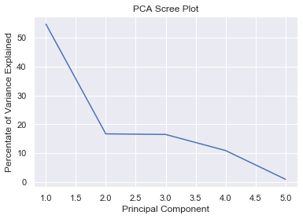

```python
from sklearn.decomposition import PCA
#run PCA
pca = PCA(n_components=5)
X_pca = pca.fit(df_scaled).transform(df_scaled)

#Scree Plot
percent_variance = np.round(pca.explained_variance_ratio_* 100, decimals =2)
plt.plot(range(1,6),percent_variance)
plt.ylabel('Percentate of Variance Explained')
plt.xlabel('Principal Component')
plt.title('PCA Scree Plot')
```

```python
#Run PCA on continuous features
pca = PCA(n_components=2)
X_sm_pca2 = pca.fit_transform(df_scaled)

#Isolate 1st 2 principal components as indicated in scree plot
prin_com = pd.DataFrame(X_sm_pca2)
prin_com = prin_com.rename(columns={0: "PC1", 1: "PC2"})
```

# Data Preparation 2

### Train and Test data sets

Standardized data sets were created to simplify and improve model creation and evaluation. All categorical variables were one hot encoded. All continuous explanatory variables were scaled. Lastly principle component variables were included in the data set as well. The response data set was the classifier column “MIS_Status” which is encoded “0” for failed loans and “1” for successful loans. All data sets take the form of pandas data frames with the same index numbers used throughout.

Since the data set is extremely large , almost 900K records, it was possible to create a separate test data set from 30% of the data. The remaining 70% of the data was adequate for training purposes. A specialized “gridsearch” helper function is created below that automatically takes advantage of the four different test sets.

```python
#Create Master train and test sets including PCA on scaled data for classification

from sklearn.model_selection import train_test_split

#combine principle components, one hot encoded and scaled data

df1hot = loans[['NAICS_1', 'NAICS_2', 'NAICS_3',
                   'NAICS_4', 'NAICS_5', 'NAICS_6', 'NAICS_7', 'NAICS_8', 'NAICS_9',
                   'ApprovalFY_decade_(1970, 1980]', 'ApprovalFY_decade_(1980, 1990]',
                   'ApprovalFY_decade_(1990, 2000]', 'ApprovalFY_decade_(2000, 2010]',
                   'ApprovalFY_decade_(2010, 2020]', 'UrbanRural_0', 'UrbanRural_1',
                   'UrbanRural_2', 'NewExist_0', 'NewExist_1', 'NewExist_2',
                   'State_midwest', 'State_northeast', 'State_southeast',
                   'State_southwest', 'State_west']]

dfscaled = df_scaled[['NoEmp', 'Term', 'DisbursementGross', 'difference_in_days']]

dfcombined = pd.concat([df1hot, dfscaled, prin_com], axis=1, join='inner')

# dataframe for the classifier response MIS_status as 0 or 1
dfrspcl = loans[['MIS_Status']] # nest values to create dataframe for results

# create dataframes for master train and test sets on scaled data. Data is split 70% train, 30% test
X_mtrain_cl, X_mtest_cl, y_mtrain_cl, y_mtest_cl = train_test_split(dfcombined, dfrspcl, test_size = .3, random_state = 42)

print(X_mtrain_cl.shape, X_mtrain_cl.columns)
print(X_mtest_cl.shape, X_mtest_cl.columns)
print(y_mtrain_cl.shape, y_mtrain_cl.columns)
print(y_mtest_cl.shape, y_mtest_cl.columns)
```

```
(627747, 31) Index(['NAICS_1', 'NAICS_2', 'NAICS_3', 'NAICS_4', 'NAICS_5', 'NAICS_6',
       'NAICS_7', 'NAICS_8', 'NAICS_9', 'ApprovalFY_decade_(1970, 1980]',
       'ApprovalFY_decade_(1980, 1990]', 'ApprovalFY_decade_(1990, 2000]',
       'ApprovalFY_decade_(2000, 2010]', 'ApprovalFY_decade_(2010, 2020]',
       'UrbanRural_0', 'UrbanRural_1', 'UrbanRural_2', 'NewExist_0',
       'NewExist_1', 'NewExist_2', 'State_midwest', 'State_northeast',
       'State_southeast', 'State_southwest', 'State_west', 'NoEmp', 'Term',
       'DisbursementGross', 'difference_in_days', 'PC1', 'PC2'],
      dtype='object')
(269035, 31) Index(['NAICS_1', 'NAICS_2', 'NAICS_3', 'NAICS_4', 'NAICS_5', 'NAICS_6',
       'NAICS_7', 'NAICS_8', 'NAICS_9', 'ApprovalFY_decade_(1970, 1980]',
       'ApprovalFY_decade_(1980, 1990]', 'ApprovalFY_decade_(1990, 2000]',
       'ApprovalFY_decade_(2000, 2010]', 'ApprovalFY_decade_(2010, 2020]',
       'UrbanRural_0', 'UrbanRural_1', 'UrbanRural_2', 'NewExist_0',
       'NewExist_1', 'NewExist_2', 'State_midwest', 'State_northeast',
       'State_southeast', 'State_southwest', 'State_west', 'NoEmp', 'Term',
       'DisbursementGross', 'difference_in_days', 'PC1', 'PC2'],
      dtype='object')
(627747, 1) Index(['MIS_Status'], dtype='object')
(269035, 1) Index(['MIS_Status'], dtype='object')
```

### Balanced data set using undersampling

The response variable in the data set is unbalanced. Approximately one sixth of the responses indicate a failed loan. The remaining five sixths responses indicate successful loans. Balanced training sets with equal numbers of failed and successful loans were created using under sampling.

```python
#create balanced response set out of just training data. We have more 1's than 0's so find the number of 0's and
#undersample from the 1's. All final datasets will still be Pandas Dataframes

# first get the indexes for all 0's and all 1's

y_mtrain_cl_1_idx = y_mtrain_cl.loc[y_mtrain_cl.MIS_Status==1].index.values.tolist()
y_mtrain_cl_0_idx = y_mtrain_cl.loc[y_mtrain_cl.MIS_Status==0].index.values.tolist()

#Create data sets that correspond to the response variable while preserving the original index

X_mtrain_cl_0 = X_mtrain_cl[X_mtrain_cl.index.isin(y_mtrain_cl_0_idx)]
y_mtrain_cl_0 = y_mtrain_cl[y_mtrain_cl.index.isin(y_mtrain_cl_0_idx)]

X_mtrain_cl_1 = X_mtrain_cl[X_mtrain_cl.index.isin(y_mtrain_cl_1_idx)]
y_mtrain_cl_1 = y_mtrain_cl[y_mtrain_cl.index.isin(y_mtrain_cl_1_idx)]

# create an undersample of correct length from the 1's. must have the same number of entries as the 0's datasets
countSamples = y_mtrain_cl_0.shape[0]

X_mtrain_cl_1_sub = X_mtrain_cl_1.sample(n=countSamples, random_state=42)

#get the index so we can pick the corresponding y's

subsample_1s_idx = X_mtrain_cl_1_sub.index.values.tolist()
y_mtrain_cl_1_sub = y_mtrain_cl_1[y_mtrain_cl_1.index.isin(subsample_1s_idx)]

#Combined undersampled 1's with original 0's to form undersampled data

X_mtrain_cl_us = pd.concat([X_mtrain_cl_0, X_mtrain_cl_1_sub])
y_mtrain_cl_us = pd.concat([y_mtrain_cl_0, y_mtrain_cl_1_sub])

print(X_mtrain_cl_us.shape, X_mtrain_cl_us.columns)
print(y_mtrain_cl_us.shape, y_mtrain_cl_us.columns)
```

```
(222350, 31) Index(['NAICS_1', 'NAICS_2', 'NAICS_3', 'NAICS_4', 'NAICS_5', 'NAICS_6',
       'NAICS_7', 'NAICS_8', 'NAICS_9', 'ApprovalFY_decade_(1970, 1980]',
       'ApprovalFY_decade_(1980, 1990]', 'ApprovalFY_decade_(1990, 2000]',
       'ApprovalFY_decade_(2000, 2010]', 'ApprovalFY_decade_(2010, 2020]',
       'UrbanRural_0', 'UrbanRural_1', 'UrbanRural_2', 'NewExist_0',
       'NewExist_1', 'NewExist_2', 'State_midwest', 'State_northeast',
       'State_southeast', 'State_southwest', 'State_west', 'NoEmp', 'Term',
       'DisbursementGross', 'difference_in_days', 'PC1', 'PC2'],
      dtype='object')
(222350, 1) Index(['MIS_Status'], dtype='object')
```

### Data Sets representing continuous variables with PCA and non PCA attributes

The master data sets contain both PCA and non PCA continuous variables. Subsets of the master data sets that contain either PCA or continuous variables were created. As a reminder all continuous variables are scaled.

```python
# Create dataset with no PCA data only the continuous variables

X_mtrain_cl_npca = X_mtrain_cl.drop(['PC1','PC2'], axis=1)
X_mtrain_cl_us_npca = X_mtrain_cl_us.drop(['PC1','PC2'], axis=1)
X_mtest_cl_npca = X_mtest_cl.drop(['PC1','PC2'], axis=1)

# Create dataset with PCA data only, no continuous variables

X_mtrain_cl_pca = X_mtrain_cl.drop(['NoEmp', 'Term', 'DisbursementGross', 'difference_in_days'], axis=1)
X_mtrain_cl_us_pca = X_mtrain_cl_us.drop(['NoEmp', 'Term', 'DisbursementGross', 'difference_in_days'], axis=1)
X_mtest_cl_pca = X_mtest_cl.drop(['NoEmp', 'Term', 'DisbursementGross', 'difference_in_days'], axis=1)
```

### Data sets for Regression

The second problem solved in this paper uses regression. However, regression is applied only over the subset of loans that failed. The regression models attempt to predict the amount of failure for the loan. The data set utilizes the same 70-30 train test split as the base classification data sets. However it only includes records where the “MIS_Status” indicates a failed loan

```python
# Data for Regression
# We want only data for failed loans that have a postive value for chrgoffpriciple
# We drop less than 2K records by specifying a positive chrgoffpriciple

# Identify indexes of failed laons with posiitve chrgoffprinciple

failed_loan_idx = loans.loc[(loans.MIS_Status==0) & (loans.ChgOffPrinGr > 0)].index.values.tolist()

X_mtrain_rg = X_mtrain_cl[X_mtrain_cl.index.isin(failed_loan_idx)]

X_mtest_rg = X_mtest_cl[X_mtest_cl.index.isin(failed_loan_idx)]

train_idx = y_mtrain_cl.index.values.tolist()
test_idx = y_mtest_cl.index.values.tolist()

y_mtrain_rg = loans.loc[(loans.index.isin(failed_loan_idx)) & (loans.index.isin(train_idx)),['ChgOffPrinGr']]
y_mtest_rg = loans.loc[(loans.index.isin(failed_loan_idx)) & (loans.index.isin(test_idx)),['ChgOffPrinGr']]

print(X_mtrain_rg.shape, X_mtrain_rg.columns)
print(X_mtest_rg.shape, X_mtest_rg.columns)
print(y_mtrain_rg.shape, y_mtrain_rg.columns)
print(y_mtest_rg.shape, y_mtest_rg.columns)
```

```
(109582, 31) Index(['NAICS_1', 'NAICS_2', 'NAICS_3', 'NAICS_4', 'NAICS_5', 'NAICS_6',
       'NAICS_7', 'NAICS_8', 'NAICS_9', 'ApprovalFY_decade_(1970, 1980]',
       'ApprovalFY_decade_(1980, 1990]', 'ApprovalFY_decade_(1990, 2000]',
       'ApprovalFY_decade_(2000, 2010]', 'ApprovalFY_decade_(2010, 2020]',
       'UrbanRural_0', 'UrbanRural_1', 'UrbanRural_2', 'NewExist_0',
       'NewExist_1', 'NewExist_2', 'State_midwest', 'State_northeast',
       'State_southeast', 'State_southwest', 'State_west', 'NoEmp', 'Term',
       'DisbursementGross', 'difference_in_days', 'PC1', 'PC2'],
      dtype='object')
(47154, 31) Index(['NAICS_1', 'NAICS_2', 'NAICS_3', 'NAICS_4', 'NAICS_5', 'NAICS_6',
       'NAICS_7', 'NAICS_8', 'NAICS_9', 'ApprovalFY_decade_(1970, 1980]',
       'ApprovalFY_decade_(1980, 1990]', 'ApprovalFY_decade_(1990, 2000]',
       'ApprovalFY_decade_(2000, 2010]', 'ApprovalFY_decade_(2010, 2020]',
       'UrbanRural_0', 'UrbanRural_1', 'UrbanRural_2', 'NewExist_0',
       'NewExist_1', 'NewExist_2', 'State_midwest', 'State_northeast',
       'State_southeast', 'State_southwest', 'State_west', 'NoEmp', 'Term',
       'DisbursementGross', 'difference_in_days', 'PC1', 'PC2'],
      dtype='object')
(109582, 1) Index(['ChgOffPrinGr'], dtype='object')
(47154, 1) Index(['ChgOffPrinGr'], dtype='object')
```

# Model and Evaluation 1

#### Task 1: Classificaiton

For classification tasks in this project the **F1-Score**, a custom metric called "Mean True Accuracy Squared" (**MTAS**), and confusion matrices will be used to measure model performance.

##### F1-Score

**F1-Score** is used for measuring classification performance and is the harmonic mean between precision and recall. Where precision is a ratio of true positives for set of items selected, and recall is a proportion of true positives that are identified in all positive classifications. This metric was chosen to measure our model performance because it incorporates both precision and recall. To generate a model with the best blend of both precision and recall the f1-score should be maximized.

##### MTAS

The data set we are classifying has an unbalanced response variable. Approximately five loans succeed for every loan that fails. Unlike in other unbalanced response problems neither the positive nor the negative response is necessarily favored for our model development. Thus, ideally, we would seek to optimize acceptable levels of accuracy for both true positive and true negative response. A new measure or scorer is needed that can be used in automated parameter searches such as “GridSearchCV”. Accuracy does examine both the positive and negative responses, but it does have a fatal flaw, “Accuracy” tends to favor one part of an unbalanced response over the other. As an example, if using accuracy, it is simple to get a model that is about 83% accurate for this data set, just predict that every loan succeeds.

A new metric was created, Mean True Accuracy Squared or *MTAS* for short.

$$MTAS = \frac{\left(\frac{True Positive}{Total Actual Positive}\right)^2 + \left(\frac{True Negative}{Total Actual Negative}\right)^2}{2}$$

*Mean:* Separate scores are created for the True and False responses. The results are averaged together.

*True Accuracy:* Each score is evaluated independently and measures the total predicted response divided by the actual responses for False and True, respectively.

*Squared:* Before the True Accuracy scores are averaged together each term is itself squared. The intention of this is to introduce a “penalty” into the process. Since increases in the value of one True Accuracy score typically come at the cost of decreases in the other True Accuracy score the penalty is designed to produce more middle of the road scores on both sides, lower highs balanced against higher lows.

As an example, consider the following two confusion matrixes(these results are from the Naive Bayes classifier model below:

| Scorer is Accuracy |  | Smoothing=0.70 |
| --- | --- | --- |
|  | Prediction |  |
| Actual | False | True |
| False | 44290 | 66885 |
| True | 22071 | 494501 |

True Negative score trained with Accuracy: 44290/(44920+66885) = 0.398

True Positive score trained with Accuracy: 494501/(494501+22071) = 0.957

MTAS trained with Accuracy: (0.398^ + 0.957^2) = 0.537

| Scorer is MTAS |  | Smoothing=0.64 |
| --- | --- | --- |
|  | Prediction |  |
| Actual | False | True |
| False | 55701 | 55474 |
| True | 39263 | 477309 |

True Negative score trained with MTAS: 55701/(55701+55474) = 0.501

True Positive score trained with MTAS: 477309/(477309+39263) = 0.924

MTAS trained with MTAS: (0.501^2 + 0.924^2)/2 = 0.552

It is incumbent upon the data scientist to determine if this scoring method is appropriate for their problem, consider these factors in reaching a decision. MTAS cannot be directly compared to other scoring methods, the raw number does not tell us anything vs accuracy or F1, etc.… The value of MTAS was left squared since this is intended to be used by machines to score models. Taking the square root of the results would only add another calculation step. When examining run time for the models created above the MTAS scored model actual runs slightly faster than accuracy scored model. MTAS would only provide benefits for unbalanced responses where balancing the True positive and True negative score is desirable.

```python
# New accuarcy measure MTAS - Mean True Accuracy Squared
from sklearn.metrics import f1_score
from sklearn.metrics import mean_squared_error
from sklearn.metrics import mean_absolute_error
from sklearn.metrics import accuracy_score
from sklearn.metrics import make_scorer
from sklearn import metrics as mt

def MTAS(ytest, yhat):
    # total number of records
    total_num = ytest.size

    # number of actual positive and negative responses in the test data
    Positive = np.sum(ytest)
    Negative = total_num - Positive

    # Find the number of True Positives and True Negatives
    TP = np.sum(ytest[yhat == 1])
    TN = np.sum(np.logical_not(ytest[yhat == 0]))

    # convert to float and Calculate score

    rv = ((TP.astype(float)/Positive.astype(float))**2 + (TN.astype(float)/Negative.astype(float))**2)/2
    #    ((TP/(TP + FN))**2 + (TN/(TN + FP))**2)/2
    # Measure the poportion of class predicted against total count of class for both classes
    # Squared term is a penalty because the difference between .9 - .5 < .9**2 - .5**2 for
    # classifiers with a greater than even chance of being right

    return rv
```

```python
# Code for MTAS explanation
from sklearn.model_selection import GridSearchCV
from sklearn.naive_bayes import GaussianNB

smoothing_values = [.6, .62, .64, .66, .68, .7, .72, .74]

param_grid = [{'var_smoothing':smoothing_values}]

scoring = {'Accuracy': make_scorer(accuracy_score),
           'MTAS': make_scorer(MTAS)}

NBG_acc = GridSearchCV(estimator = GaussianNB(),
                        param_grid=param_grid,
                        scoring=scoring,
                        cv = 10, n_jobs=-1, verbose=1, refit='Accuracy', return_train_score=True)

NBG_acc.fit(X_mtrain_cl_npca, y_mtrain_cl)

cv_results_NBG_acc = NBG_acc.cv_results_
best_estimator_NBG_acc = NBG_acc.best_estimator_
best_index_NBG_acc = NBG_acc.best_index_
best_score_NBG_acc = NBG_acc.best_score_
best_params_NBG_acc = NBG_acc.best_params_

NBG_MTAS = GridSearchCV(estimator = GaussianNB(),
                        param_grid=param_grid,
                        scoring=scoring,
                        cv = 10, n_jobs=-1, verbose=1, refit='MTAS', return_train_score=True)

NBG_MTAS.fit(X_mtrain_cl_npca, y_mtrain_cl)

cv_results_NBG_MTAS = NBG_MTAS.cv_results_
best_estimator_NBG_MTAS = NBG_MTAS.best_estimator_
best_index_NBG_MTAS = NBG_MTAS.best_index_
best_score_NBG_MTAS = NBG_MTAS.best_score_
best_params_NBG_MTAS = NBG_MTAS.best_params_

from sklearn import metrics as mt

print(best_estimator_NBG_acc)
y_hat_cl_npca_acc = best_estimator_NBG_acc.predict(X_mtrain_cl_npca)
cm_npca_acc = mt.confusion_matrix(y_mtrain_cl,y_hat_cl_npca_acc)
print("Confusion matrix Model trained with accuracy scorer non PCA data")
print(cm_npca_acc)

y_hat_cl_npca_MTAS = best_estimator_NBG_MTAS.predict(X_mtrain_cl_npca)
cm_npca_MTAS = mt.confusion_matrix(y_mtrain_cl,y_hat_cl_npca_MTAS)
print("Confusion matrix Model trained with MTAS scorer non PCA data")
print(cm_npca_MTAS)
```

```
Fitting 10 folds for each of 8 candidates, totalling 80 fits
```

```
[Parallel(n_jobs=-1)]: Using backend LokyBackend with 24 concurrent workers.
[Parallel(n_jobs=-1)]: Done   2 tasks      | elapsed:    6.0s
[Parallel(n_jobs=-1)]: Done  80 out of  80 | elapsed:   19.5s finished
```

```
Fitting 10 folds for each of 8 candidates, totalling 80 fits
```

```
[Parallel(n_jobs=-1)]: Using backend LokyBackend with 24 concurrent workers.
[Parallel(n_jobs=-1)]: Done   2 tasks      | elapsed:    4.8s
[Parallel(n_jobs=-1)]: Done  80 out of  80 | elapsed:   18.4s finished
```

```
GaussianNB(priors=None, var_smoothing=0.7)
Confusion matrix Model trained with accuracy scorer non PCA data
[[ 44290  66885]
 [ 22071 494501]]
Confusion matrix Model trained with MTAS scorer non PCA data
[[ 55701  55474]
 [ 39263 477309]]
```

#### Task 2: Regression

##### MAE

For Task 2, the mean absolute error (**MAE**) will be used to measure model performance. MAE is a measurement of the mean magnitude of errors between predicted values and actual values. For our regression model, **ChgOffPrinGr** was selected as the response. This feature captures the amount of money remaining on a loan when it charged-off. MAE is the chosen metric for regression model performance because it easy to interpret as its value explains the dollar value the model varies by.

# Model and Evaluation 2

Stratified K-Fold cross validation was used to create training and testing sets for use in grid search. This method of cross validation because each fold is representative of the original dataset. This is good for imbalanced data, such as the SBA dataset as it maintains the proportion of records across features for each fold; in normal cross validation, if there is a class within a feature with a low volume of observations, it may not be present in one of the folds. By stratifying the folds this issue is mitigated.

For cross validation the 70% training data set shown in the "Data Preparation 2" section was used to train the models, while the final model performance measurement of grid-searched models was preformed using the 30% testing data set. Please see the "Data Preparation 2" section for more details.

A gridsearch() helper function was created help to tune hyperparameters, display final performance metrics, and return CV metrics. The gridsearch() function takes in the following arguments: model, the model name, a parameter grid, training and testing data, model type (classifier or regression), and a cross validation object. Once the helper function has the following arguments it performs a grid search, runs a fit on the model generated by grid search using the test data, outputs model performance and cv metrics, and outputs a plot of the f1-score by response class for classification models. The helper function also has the argument notations inside of the function to clearly define what each input for each argument should be and sets n_jobs to -1 to allow for multi-core parallelization.

```python
from sklearn.model_selection import GridSearchCV
from sklearn.model_selection import StratifiedKFold
import time

def per_class_accuracy(ytrue,yhat):
    conf = mt.confusion_matrix(ytrue,yhat)
    norm_conf = conf.astype('float') / conf.sum(axis=1)[:, np.newaxis]
    return np.diag(norm_conf)

def plot_class_acc(ytrue,yhat, title=''):
    acc_list = per_class_accuracy(ytrue,yhat)
    plt.bar(range(len(acc_list)), acc_list)
    plt.xlabel('Class value')
    plt.ylabel('f1-score within class')
    plt.title(title+", Total f1-Score=%.1f"%(100*mt.f1_score(ytrue,yhat)))
    plt.grid()
    plt.ylim([0,1])
    plt.show()

cv = StratifiedKFold(n_splits=2,shuffle=True, random_state=42)
def gridsearch(model,modelName, grid, rf, scoring, x_test, y_test, X_train, y_train,modelType = 0, cv=cv):
    # model - input model object
    # grid - parameters used for gridsearch
    # rf - refit parameter for gridsearch aka performance metric
    # scoring - metric of choice for model preformance
    # x_test - testing df
    # X_train - features
    # y_train - target
    # cv - cv object

    start = time.time() #Start timer
    #Preform Grid Search and get predictions
    cv_results = GridSearchCV(model, grid, cv=cv, scoring = scoring, refit = rf, return_train_score = True, n_jobs=-1)
    cv_results.fit(X_train,y_train)  # train object
    y_hat = cv_results.predict(x_test)
    elapsed_time = (time.time() - start)  #end timer

    if modelType == 'classifier':
        #print out preformance metics and confusion matrix for classification
        #########################################################
        print('MTAS score: ', MTAS(y_test,y_hat))
        print('F1 Score : ' + str(f1_score(y_test,y_hat)))
        print('Grid Search Time: ', elapsed_time)
        print("==== Confusion Matrix ====")
        print("\nconfusion matrix\n",mt.confusion_matrix(y_test,y_hat))
        print("\nPer Class Accuracy\n")
        plot_class_acc(y_test,y_hat, title=modelName)
    else:
        #print out preformance metics for regression
        #########################################################
        print('MAE Score : ', mean_absolute_error(y_test,y_hat))
        print('Grid Search Time: ', elapsed_time)
        #[cv_results.best_estimator_,cv_results.best_score_, cv_results.best_params_]
    return [cv_results.best_estimator_,cv_results.best_score_, cv_results.best_params_] #return grid search results
```

# Model and Evaluation 3

Random Forest, Naive Bayes, and Logistic Regression were used for Task 1 to classify **MIS_Status**. Where "P I F" is a success, and "CHGOFF" is a failure. For each model, a grid search was preformed to tune the hyper parameters to allow for optimal performance metrics.

Random Forest, KNN, and Linear Regression were used for Task 2 to predict charge-off principal gross values. For these models, data was filtered for records that had a "CHGOFF". These records have an associated Charge-off Principal Gross to capture the amount of money that remained on a loan after it was charged-off. For each model, a grid search was preformed to tune the hyper parameters to allow for optimal performance metrics.

## Task 1: Random Forest Classification

The gridsearch() helper function was used to intake the necessary data and parameters to perform a grid search. An exhaustive search across all Random Forest parameters would have generated more optimal results; however, since there are many parameters to adjust and the dataset is very large, three parameters were chosen to tune hyperparameters for a more rapid cross validation and parameter tuning process.

For hyperparameter tuning the three parameters selected were: 'min_samples_leaf', 'min_samples_split', and 'n_estimators'. The 'min_samples_leaf' parameters controls the minimal number of records in a leaf node; the 'min_samples_split' controls the minimum number of records in a node before it is split; and 'n_estimators' controls the number of trees that are in the forest. Each parameter has 3 different settings, totaling 27 settings that were tested through grid search.

A confusion matrix was run by taking predictions from a model fit on the best parameters generated by the grid search and comparing them to the 30% hold-out test set created in the "Data Preparation 2" section. The benefit of having a separate hold-out test set in addition to the CV process utilized, was that model performance was judged on data that the trained model was never exposed to. This allows for better performance measuring. The confusion matrix confirmed that the f1-score and MTAS were good measures. This was determined by looking at the ratio of true positives and true negatives. The ratio of "P I F" and "CHGOFF" from the "Data Preparation 1" section was approximately 17%. When looking at the confusion matrix the ratio was approximately 14%. This suggests that the tuned model can correctly classify our response.

Additionally, a per class f1-score plot was printed out. The model identifies "P I F" observations very well, where as "CHGOFF" detections were acceptable. This is due to the unbalanced nature of the dataset as "CHGOFF" does not occur as frequently as "P I F". However, given the confusion matrix generated after the grid search the difference between "P I F" and "CHGOFF" for the whole data set and the confusion matrix is ~3% (CHGOFF is ~17% of the whole dataset, ~14% of the training hold-out set).

```
MTAS score:  0.7327980193534491
F1 Score : 0.9557244901142091
Grid Search Time:  1848.2816553115845
==== Confusion Matrix ====

confusion matrix
 [[ 34686  13174]
 [  6698 214477]]

Per Class Accuracy
```

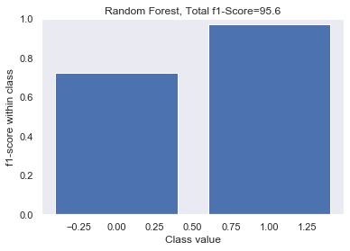

```
[RandomForestClassifier(bootstrap=True, ccp_alpha=0.0, class_weight=None,
                        criterion='gini', max_depth=50, max_features='auto',
                        max_leaf_nodes=None, max_samples=None,
                        min_impurity_decrease=0.0, min_impurity_split=None,
                        min_samples_leaf=2, min_samples_split=5,
                        min_weight_fraction_leaf=0.0, n_estimators=200,
                        n_jobs=-1, oob_score=True, random_state=None, verbose=0,
                        warm_start=False),
 0.9550811023710825,
 {'min_samples_leaf': 2, 'min_samples_split': 5, 'n_estimators': 200}]
```

```python
from sklearn.ensemble import RandomForestClassifier
#data for model and preformance measuring
X = X_mtrain_cl
y = y_mtrain_cl.values.ravel()
x_test = X_mtest_cl
y_test = y_mtest_cl.values.ravel()

#initialize model and cv objects
rfc = RandomForestClassifier(max_depth=50, n_estimators=150, n_jobs=-1, oob_score=True)
cv = StratifiedKFold(n_splits=4, shuffle=True, random_state=42)

#set up parameters and metrics to tune hyperparameters by
grid = {'min_samples_leaf':[2, 5, 10],
        'min_samples_split': [5, 10, 15],
        'n_estimators': [100, 200, 300]}
rf = "f1"
scoring = {'f1': make_scorer(f1_score),
           'MTAS':make_scorer(MTAS)}

#execute grid search
gridsearch(rfc,"Random Forest",grid, rf, scoring, x_test, y_test, X, y,'classifier', cv=cv)#12:42AM
```

## Task 1: Naive Bayes Classification

A Naive Bayes model was trained for classification. Initially the model was scored using F1, and MTAS. Also, models trained on the PCA data set were created. The PCA trained models did not return any predictions for negative outcomes. Since the models predicted that no loans would fail, the PCA trained models were discarded.

Additionally, the Naïve Bayes model was trained with the under sampled data set. The results were not useful having a low F1 and MTAS scores. However, a special use for these models might exist. The models captured 87.6% of the true negatives. (0.876 = 41942/(41942 + 5918)). This comes at a cost of creating more than two and a half times the false negative as really exist. If a business requirement necessitated predicting as many negative outcomes as possible and the costs associated with a high false negative count are not too great this models results might be of interest.

```
MTAS score:  0.5513775669783426
F1 Score : 0.9091418844497846
Grid Search Time:  27.185625791549683
==== Confusion Matrix ====

confusion matrix
 [[ 23911  23949]
 [ 16884 204291]]

Per Class Accuracy
```

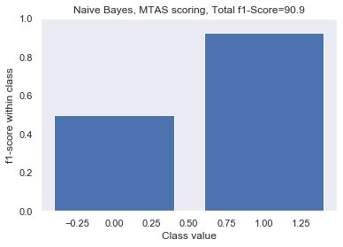

```
MTAS score:  0.5310004521090664
F1 Score : 0.9181175429895244
Grid Search Time:  27.208118677139282
==== Confusion Matrix ====

confusion matrix
 [[ 17090  30770]
 [  7367 213808]]

Per Class Accuracy
```

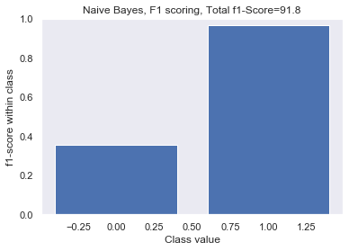

```
MTAS score:  0.5084580927409008
F1 Score : 0.6485129497109878
Grid Search Time:  9.033715009689331
==== Confusion Matrix ====

confusion matrix
 [[ 42121   5739]
 [112290 108885]]

Per Class Accuracy
```

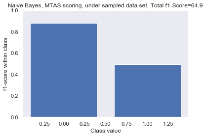

```
MTAS score:  0.5084021668620322
F1 Score : 0.653940649459574
Grid Search Time:  8.92313838005066
==== Confusion Matrix ====

confusion matrix
 [[ 41942   5918]
 [110849 110326]]

Per Class Accuracy
```

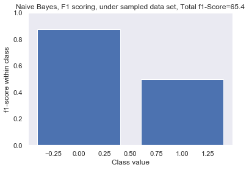

```python
# Naive Bayes Accuracy score
#sklearn.naive_bayes.GaussianNB(*, priors=None, var_smoothing=1e-09
from sklearn.naive_bayes import GaussianNB

smoothing_values = [.6, .62, .64, .66, .68, .7, .72, .74, .76, .78, .8]

param_grid = [{'var_smoothing':smoothing_values}]

scoring = {'f1': make_scorer(f1_score),
           'MTAS':make_scorer(MTAS)}

nbc =  GaussianNB()

rf = 'MTAS'

cv = StratifiedKFold(n_splits=10, shuffle=True, random_state=42)

X = X_mtrain_cl_npca
y = y_mtrain_cl.values.ravel()
x_test = X_mtest_cl_npca
y_test = y_mtest_cl.values.ravel()

NB_clf_Estimator, NB_clf_Score, NB_clf_Params = gridsearch(nbc,"Naive Bayes, MTAS scoring",param_grid, rf, scoring, x_test, y_test
                                                           , X, y,'classifier', cv=cv)

rf = 'f1'
NB_clf_Estimator_f1, NB_clf_Score_f1, NB_clf_Params_f1 = gridsearch(nbc,"Naive Bayes, F1 scoring",param_grid, rf, scoring, x_test, y_test
                                                           , X, y,'classifier', cv=cv)

# use undersampled data

X = X_mtrain_cl_us_npca
y = y_mtrain_cl_us.values.ravel()

rf = 'MTAS'
NB_us_clf_Estimator, NB_us_clf_Score, NB_us_clf_Params = gridsearch(nbc,"Naive Bayes, MTAS scoring, under sampled data set",param_grid, rf, scoring, x_test, y_test
                                                           , X, y,'classifier', cv=cv)

rf = 'f1'
NB_us_clf_Estimator_f1, NB_us_clf_Score_f1, NB_us_clf_Params_f1 = gridsearch(nbc,"Naive Bayes, F1 scoring, under sampled data set",param_grid, rf, scoring, x_test, y_test
                                                           , X, y,'classifier', cv=cv)
```

## Task 1: Logistic Regression Classification

A Logisitic Regression model was also trained for classification. The model was scored using F1, and MTAS for the score parameter of the grid search. Cost values were also tested in the grid search with the np.logspace() function.

When preforming a grid search based on the MTAS metric, comparable results were found, with both F1-Score and MTAS models returning a cost value of 1.0.

```python
from sklearn.linear_model import LogisticRegression
lr_clf = LogisticRegression(penalty='l2', solver='liblinear', random_state=42)
C = np.logspace(0, 4, 12)
param_grid = {'C': C}
score = {'f1': make_scorer(f1_score),
        'MTAS':make_scorer(MTAS)}
```

```
MTAS score:  MIS_Status    0.516656
dtype: float64
F1 Score : 0.9154619528805722
Grid Search Time:  375.24589347839355
==== Confusion Matrix ====

confusion matrix
 [[ 14078  33782]
 [  5965 215210]]

Per Class Accuracy
```

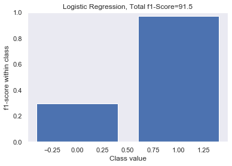

```python
# Create grid search using 5-fold cross validation
# gridsearch(model,modelName, grid, rf, scoring, x_test, y_test, X_train, y_train,modelType = 0, cv=cv):

x_test = X_mtest_cl
y_test = y_mtest_cl
X_us2= X_mtrain_cl
y_us2= y_mtrain_cl

#Run gridsearch
cv = StratifiedKFold(n_splits =10, shuffle = True, random_state=42)
clf = gridsearch(lr_clf,'Logistic Regression',param_grid,'f1', score,  x_test, y_test, X_us2, y_us2, 'classifier', cv)
```

Cross validation results are displayed below. The output of clf show the best model, the final preformance metric of the best model, and the best parameters that grid search determined.

```python
clf
```

```
[LogisticRegression(C=1.0, class_weight=None, dual=False, fit_intercept=True,
                    intercept_scaling=1, l1_ratio=None, max_iter=100,
                    multi_class='auto', n_jobs=None, penalty='l2',
                    random_state=42, solver='liblinear', tol=0.0001, verbose=0,
                    warm_start=False),
 0.9156287274923652,
 {'C': 1.0}]
```

```
MTAS score:  MIS_Status    0.516656
dtype: float64
F1 Score : 0.9154619528805722
Grid Search Time:  375.229380607605
==== Confusion Matrix ====

confusion matrix
 [[ 14078  33782]
 [  5965 215210]]

Per Class Accuracy
```

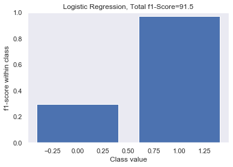

```python
clf2 = gridsearch(lr_clf,'Logistic Regression',param_grid,'MTAS', score,  x_test, y_test, X_us2, y_us2, 'classifier', cv)
```

Cross validation results are displayed below. The output of clf2 show the best model, the final preformance metric of the best model, and the best parameters that grid search determined.

```python
clf2
```

```
[LogisticRegression(C=1.0, class_weight=None, dual=False, fit_intercept=True,
                    intercept_scaling=1, l1_ratio=None, max_iter=100,
                    multi_class='auto', n_jobs=None, penalty='l2',
                    random_state=42, solver='liblinear', tol=0.0001, verbose=0,
                    warm_start=False),
 0.5162039197212319,
 {'C': 1.0}]
```

## Task 2: Random Forest Regression

A 4-fold cross-validation using a Random Forest regressor with model performance judged on the mean-absolute error was run. Data frames were fed into the algorithm for both training and testing, where the target feature for both training and test sets were converted to arrays for model use. The model, cross-validation object, and data were put into the stratified_cross_validate() helper function and run with 4-folds. The mean MAE score was 80388.94 and the CV time was approximately 1300 seconds.

The gridsearch() helper function was used to intake the necessary data and parameters to perform a grid search. An exhaustive search across all Random Forest parameters would have generated more optimal results. However, since there are many parameters to adjust and the dataset is very large, three parameters were chosen to tune hyper parameters for the sake of a more rapid cross validation and parameter tuning process.

```python
from sklearn.ensemble import RandomForestRegressor

X = X_mtrain_rg
y = y_mtrain_rg.values.ravel()
x_test = X_mtest_rg
y_test = y_mtest_rg.values.ravel()

rf_reg = RandomForestRegressor(oob_score = True, n_jobs = -1, random_state = 42)

#parameters to tune
grid = {'n_estimators': [100,200,300],
        'min_samples_leaf':[1, 2, 5, 10],
        'min_samples_split': [5, 10, 15]
       }
#metrics for measuring preformance
scoring = {'MAE': make_scorer(mean_absolute_error)}

cv = StratifiedKFold(n_splits=4, shuffle=True, random_state=42)
rf = "MAE"
rf_cv = gridsearch(model = rf_reg,modelName = 'Random Forest', grid = grid, rf = rf, scoring = scoring, x_test = x_test, y_test = y_test,
           X_train = X, y_train = y, modelType='regression', cv=cv)
```

```
MAE Score :  80388.94469473587
Grid Search Time:  1286.135401725769
```

Cross validation results are displayed below. The output of rf_cv show the best model, the final preformance metric of the best model, and the best parameters that grid search determined.

```python
rf_cv
```

```
[RandomForestRegressor(bootstrap=True, ccp_alpha=0.0, criterion='mse',
                       max_depth=None, max_features='auto', max_leaf_nodes=None,
                       max_samples=None, min_impurity_decrease=0.0,
                       min_impurity_split=None, min_samples_leaf=1,
                       min_samples_split=5, min_weight_fraction_leaf=0.0,
                       n_estimators=100, n_jobs=-1, oob_score=True,
                       random_state=42, verbose=0, warm_start=False),
 81418.66919621,
 {'min_samples_leaf': 1, 'min_samples_split': 5, 'n_estimators': 100}]
```

### Task 2: KNN Regression

kNN regression was performed on the data set. The “n_neighbors” and “leaf_size” parameters were adjusted in a grid search. “n_neighbors” refers to how many neighbors of the data point are examined. “leaf_size” refers to how many records are stored in a leaf for BallTree and KDTree algorithms. The algorithm parameter itself was left as “auto” so it could determine the best algorithm to use. The best mean absolute error was obtained by running the model with parameters n_neighbors = 4 and leaf_size = 50, the MAE is 83795. The GridSearch helper function was used to test different combinations of parameters. kNN regression did run for a considerable length of time. Six different parameters were tried for “n_neighbors” and 3 for “leaf_size”.

```python
from sklearn.neighbors import KNeighborsRegressor

X = X_mtrain_rg
y = y_mtrain_rg.values.ravel()
x_test = X_mtest_rg
y_test = y_mtest_rg.values.ravel()

knn_reg = KNeighborsRegressor(n_neighbors=2, p=2, algorithm='kd_tree')
knn_reg.fit(X,y)
y_hat_knn = knn_reg.predict(x_test)

# Use gridsearchCV
grid = {'n_neighbors': [4,6,8,10,12,14],
        'algorithm': ['auto'],
        'leaf_size': [50, 100, 1000]
       }
#metrics for measuring preformance
scoring = {'MAE': make_scorer(mean_absolute_error)}

cv = StratifiedKFold(n_splits=4, shuffle=True, random_state=42)
rf = "MAE"
knn_gs = gridsearch(model = knn_reg, modelName = 'kNN Regression', grid = grid, rf = rf, scoring = scoring, x_test = x_test, y_test = y_test,
           X_train = X, y_train = y, modelType='regression', cv=cv)
```

```
MAE Score :  83795.66221847563
Grid Search Time:  1533.1717422008514
```

```python
knn_gs
```

```
[KNeighborsRegressor(algorithm='auto', leaf_size=50, metric='minkowski',
                     metric_params=None, n_jobs=None, n_neighbors=4, p=2,
                     weights='uniform'),
 84763.7747432685,
 {'algorithm': 'auto', 'leaf_size': 50, 'n_neighbors': 4}]
```

### Linear Regression

A linear and lasso regression were run to identify which linear regression method yielded the best MAE statistic. Data was converted to matrices and arrays for model ingestion and fed into the models. Data was standardized and multi-colinear features were removed in "Data Preparation 1" and "Data Preparation 2" sections.

Lasso regression is a technique that favors models with fewer coefficients. It is very flexible with high multi-collinearity and shrinks data towards the mean. Using Lasso will help deal with any remaining multi-collinearity that were not addressed in the Data Preparation sections.

```python
from sklearn.linear_model import LinearRegression
from sklearn.metrics import mean_absolute_error

Xl = X_mtrain_rg.reset_index(drop=True).values
yl = y_mtrain_rg.values
x_testl = X_mtest_rg.reset_index(drop=True).values
y_testl = y_mtest_rg.values

linear_reg = LinearRegression()
linear_reg.fit(Xl,yl)
y_hat_linear_reg = linear_reg.predict(x_testl)

linear_MAE = mean_absolute_error(y_testl, y_hat_linear_reg)

print("Linear Mean Absolute Error: ", linear_MAE)
```

```
Linear Mean Absolute Error:  73798.20672689486
```

For the Lasso grid search, the main parameter adjusted was alpha values; where smaller alpha values favor a more complex model (more coefficients), and larger alpha values favor simpler models (less coefficients). The grid variable captures the ranges of alpha to be tested, starting at 0.001 ranging to 1000. The CV object for this grid search was set to 10-folds as each fold is relatively quick to complete. The main statistic used to tune the model was set to mean absolute error. When comparing the two linear models there were marginal difference between the two. For comparison purposes, the Lasso model was used as we could adjust its parameters in grid search.

```python
from sklearn.linear_model import Lasso

X = X_mtrain_rg
y = y_mtrain_rg.values.ravel()
x_test = X_mtest_rg
y_test = y_mtest_rg.values.ravel()

reg = Lasso(random_state=42)
grid = {'alpha': [0.001,0.01,0.1,1,10,100,1000]}
scoring = {'MAE': make_scorer(mean_absolute_error)} #metrics for measuring preformance

cv = StratifiedKFold(n_splits=10, shuffle=True, random_state=42)
rf = "MAE"
lasso_cv = gridsearch(model = reg,modelName = 'Lasso Regression', grid = grid, rf = rf, scoring = scoring, x_test = x_test, y_test = y_test,
           X_train = X, y_train = y, modelType='regression', cv=cv)
```

```
MAE Score :  73803.96652447263
Grid Search Time:  31.155248880386353
```

```python
lasso_cv
```

```
[Lasso(alpha=0.001, copy_X=True, fit_intercept=True, max_iter=1000,
       normalize=False, positive=False, precompute=False, random_state=42,
       selection='cyclic', tol=0.0001, warm_start=False),
 74458.84749025403,
 {'alpha': 0.001}]
```

## Parameter Investigation

### Task 1: Classification Parameter Investigation

Considering the time, it takes to execute the classification algorithms, the Random Forest classifier is ~4% higher compared to the other classifiers. While the MTAS is ~20% better compared to the other classifiers. The question of "best classifier depends on how these algorithms will be applied.

If results from a classifiers are for an infrequently run report, the Random Forest Classifier would be best as it has the highest performance metrics; if the results need to be updated frequently the Naive Bayes would be a better option since it is much faster to run, has a comparable F1-score to Logistic Regression, but has ~4% better MTAS than Logistic Regression.

For parameter investigation the **Random Forest Classifier** was used.

```python
d = {'Classification Model':['Random Forest', 'Naive Bayes','Logistic Regression'],
     'F1-Score':[0.956,0.918,0.915], 'MTAS':[.734,0.531,0.517],'Folds':[4,10,10], 'Grid Search Time (s)':[1854.031,27.254,389.672]}
pd.DataFrame(d).style.hide_index()
```

| Classification Model | F1-Score | MTAS | Folds | Grid Search Time (s) |
| --- | --- | --- | --- | --- |
| Random Forest | 0.956000 | 0.734000 | 4 | 1854.031000 |
| Naive Bayes | 0.918000 | 0.531000 | 10 | 27.254000 |
| Logistic Regression | 0.915000 | 0.517000 | 10 | 389.672000 |

After running grid search, the best Random Forest Classifier had the parameters shown in the table below in addition to default values of:

- min_weight_fraction_leaf = 0
- max_features = 'auto'
- max_leaf_nodes=None
- min_impurity_decrease = 0
- min_impurity_split = None
- bootstrap = True
- ccp_alpha = 0
- max_samples = None

'min_samples_leaf' and 'min_samples_split' both determine stopping conditions for node/lead creation. The larger the values are, the higher tendency for a tree to over-fit the data. 'min_samples_leaf' dictates the minimum number of samples for a leaf to exist - where leaves are terminal portions of a tree that have no further nodes. While 'min_samples_split' specifies the minimum number of records to split a node that contains leafs. 'n_estimators' dictates how many trees will be run to generate a result that maximizes the performance metric of choice. For this Random Forest Classifier, grid search determined that the minimum samples per leaf was 2, the minimum samples for a split to occur was 5, and the number of trees generated to reach the best f1-score was 200 trees.

```python
rf_cv_res = {'min_samples_leaf': [2], 'min_samples_split': [5], 'n_estimators': [200]}
pd.DataFrame(rf_cv_res).style.hide_index()
```

| min_samples_leaf | min_samples_split | n_estimators |
| --- | --- | --- |
| 2 | 5 | 200 |